# Bilgi Yönetim Sistemleri - Bitirme Projesi Rapor: Begüm Önal 200401082 Barkın Oral 180401089 Kubilay Kabataş 200401089 Ramazan Eyüp Gültekin 200401003 Tugay Bakay 200401029

Bu rapor Bilgi Yönetim Sistemi dersinin Bitirme Projesi için oluşturulmuştur.

### Q1: İş probleminin tanımı

**Appa Customer Services** şirketi, danışanlarından aldığı verilerdeki değerlere göre lokasyon analizi sağlamaktadır. Danışan, müşterilerinin kişisel bilgilerinin (Adı, adresi vb.) anonimliğini gözeterek **Appa**’ya iletir. **Appa CS**, kendisine sağlanan veri üzerinden danışanın yeni şubesini/deposunu nereye açabileceğini analiz eder. Veri içe aktarma kolaylığından ötürü **Suite CRM** kullanılmaktadır.

### Q2: İş problemini çözmede kullanılacak data seti

Platforma eklenen veri seti dünya çapındaki e-ticaret verilerini barındıran temizlenmiş bir veri setidir. Veri seti Kaggle üzerinden bulunmuştur. Veri üzerinde yalnızca filtreleme ve format çalışması yapılmıştır. Sentetik veri üretilmemiştir. Ayrıca analizi iyileştirmek için şehirlerdeki hayat pahalılığı ile korelasyonu da incelenmiştir.

[Satın Alma Verileri](https://www.kaggle.com/datasets/apoorvaappz/global-super-store-dataset)  
[Hayat Pahalılığı Verileri](https://www.kaggle.com/datasets/mvieira101/global-cost-of-living?select=cost-of-living.csv) [Eyaletlerin Vergi Oranları](https://www.avalara.com/taxrates/en/state-rates.html) [Eyaletlerin Koordinatları](https://www.latlong.net/category/states-236-14.html)

### Q3: Veri seti keşifsel analizi

Aşağıdaki tabloda örnek olarak kullanılacak verinin ilk 5 satırı görülebilir:

| order_Date | customerID | city | state | country | profit |
| --- | --- | --- | --- | --- | --- |
| 2012-07-31 | RH-19495 | New York City | New York | United States | 24389.904 |
| 2014-10-14 | JW-15220 | Sacramento | California | United States | 61007.520 |
| 2012-01-28 | JH-15985 | Concord | North Carolina | United States | -59593.997 |
| 2011-04-05 | GM-14695 | Alexandria | Virginia | United States | 2664.992 |
| 2014-11-03 | TB-21175 | Henderson | Kentucky | United States | 16559.338 |

Danışan şirket için esas göz önüne alınacak veri kar olduğundan eyalet bazında ticaretten elde edilen kar grafiği aşağıdaki gibidir:

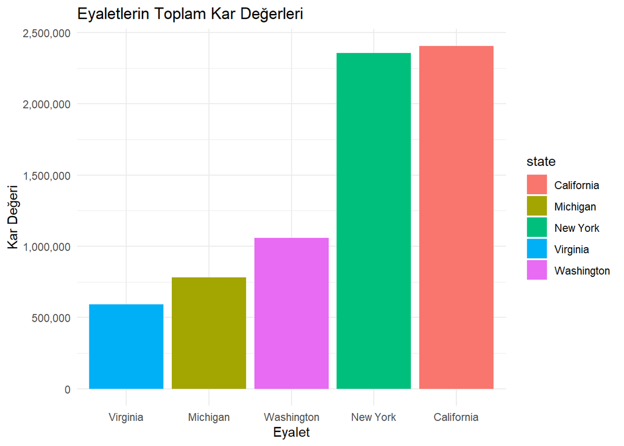

Grafikte de görüleceği gibi *New York* ve *California* eyaletlerinde elde edilen kar birbirine çok yakınken, diğer eyaletler ile aralarındaki yüksekçe bir fark bulunmakta. Bu derin fark önemli bir **indikatör** olmasına karşın daha derinlemesine bir inceleme gerekmekte ancak bu inceleme Q5’te de değinildiği üzere **APPA CS** şirketinin ana analizini kapsamaktadır.

| city | total_profit |
| --- | --- |
| New York City | 1973360.3 |
| Los Angeles | 965079.8 |
| Seattle | 926712.0 |
| San Francisco | 550015.9 |
| Detroit | 421075.5 |
| Lafayette | 320438.0 |

Ve 5 şehirde de negatif kar elde edilmektedir:

| city | total_profit |
| --- | --- |
| Philadelphia | -441359.0 |
| Houston | -314480.5 |
| San Antonio | -232218.5 |
| Lancaster | -230688.9 |
| Chicago | -202406.3 |

### Q4: Veri setinin BYS platformuna ihtali

Kullanılan CRM olan SuiteCRM’in import arayüzü kullanılarak import işlemi gerçekleştirildi. (Q6’da sağlanan videoda görülebilir)

### Q5 : Yapılması planlanan veri analizi

**Appa CS** firmasının analizini diğer analizlerden ayıran yegane fark *Volodymyr Agafonkin* tarafından sağlanan ve yine bir özgür yazılım projesi olan Leaflet’ten yararlanmaktır. Leaflet, Google servislerinin sunduğu harita hizmetinin açık kaynak halini, özgür yazılım prensiplerini benimsemiş kaynaklardan elde eder.

Sunulacak hizmet için yapılan derin analizde, kullanıcının yeni şube/deposu için kar marjinini çeşitli verilerle(hayat pahalılığı, ortalama maaş vb.) korelasyonunu incelemek, daha sonra bu verileri kümeleme yöntemi ile harita üzerindeki izdüşümünü hesaplamak ve en doğru biçimde harita üzerinde göstermeyi amaçlamaktadır.

Aşağıda kullanılacak haritanın, okulumuzun mühendislik bölümünü işaretlemiş hali incelenebilir:

[interactive chart not shown]

### Q6 : Çalışan platformun gösterildiği sesli anlatımlı video

[Bu linkten](https://youtu.be/lVmNOd4VrQA) SuiteCRM dashboard incelemesi ve Data Import işlemlerini görüntüleyebilirsiniz.

### Final Analizi (11.06.2024 Tarihinde Eklenmiştir)

Danışan şirketin açacağı yeni deponun konumunu optimize etmek için yapılacak analizde göz önüne alınacak yegane değer eyalet bazlı kar değeri olduğundan; eyaletlerin konumları, kar değeri ile ağırlıklandırarak tek bir noktaya indirgenmiştir

[interactive chart not shown]

Bu nokta, yapılan satışların her birine ağırlıklandırılmış şekildeki optimum uzaklıktır.

Ağırlıklandırılmış orta nokta *Illanois* eyaletine düşmüş olsa da bu bizi bir sonraki analizimize getirmektedir; Illanois eyaleti en karlı lokasyon mudur?

[interactive chart not shown]

Ağırlıklandırılmış noktayı 200 kilometrelik yarıçapa sahip bir çembere çevirdiğimizde karşımıza çıkan alan, üç ayrı eyaleti kapsamaktadır. Bu eyaletler (Iowa, Illinois, Missouri) danışan şirketimizin açacağı yeni depo için aday eyaletlerdir.

Bu eyaletleri değerlendirirken göz önüne alınabilecek çeşitli parametreler olsa da kar maksimizasyonu için; şirketin satışlarının, çalışan giderleri göz önüne alınarak **Hayat Pahalılığı** ve kar göz önüne alınarak **eyaletin vergi oranı** ile korelasyonu incelenmiştir:

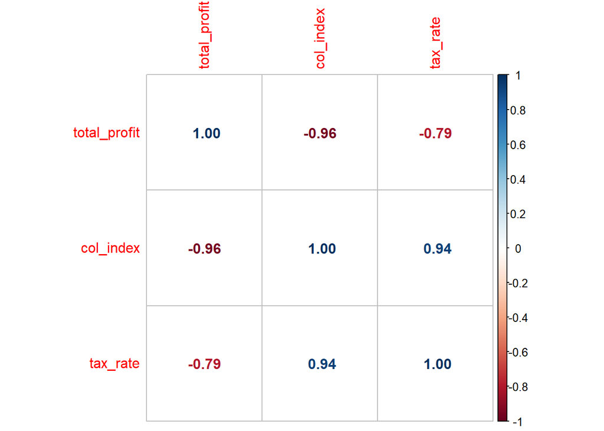

Ortaya çıkan korelasyon tablosu açıkça göstermektedir ki; şirket satışlarından elde edilen kar ile hayat pahalılığı ve eyaletin vergi oranı arasında negatif bir ilişki vardır. Dolayısıyla şirket için önerilecek bölgelerde bu verilerin minimalize edilmesi amaçlanacaktır.

Bu eyaletlerin vergi oranları incelendiğinde en az vergi oranına sahip olan eyalet **Missorui** olarak ortaya çıkmıştır:

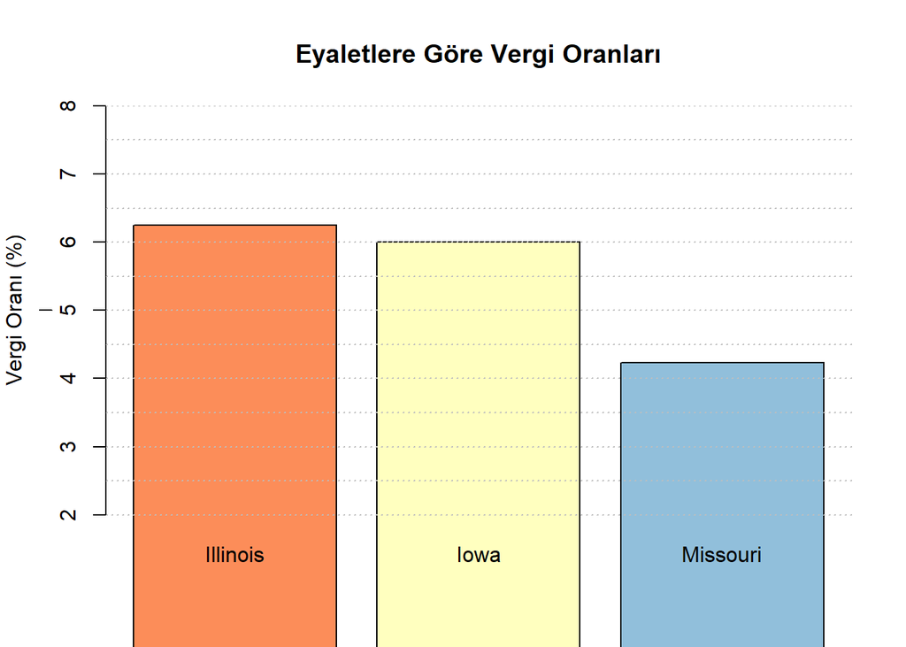

Aynı şekilde bu üç eyaletin hayat pahalılığı endeksi incelendiğinde hayat pahalılığı açısından en ucuz eyalet yine **Missorui** olmuştur:

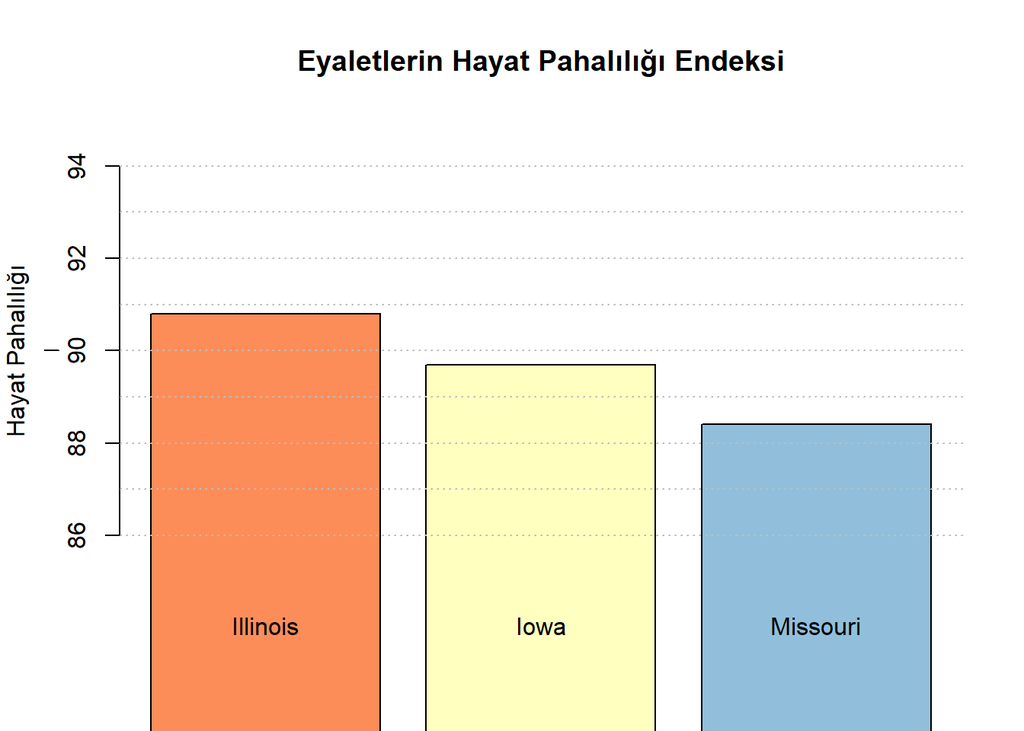

Bu analizler göstermiştir ki: Danışan şirketin yeni açacağı depo için seçilecek en makul lokasyon **Missouri** eyaletinin doğu **Kuzey-Doğu** bölgesidir.